# 見せかけの回帰

```r
library(urca)
library(lmtest)
library(prais)
library(tidyverse)
library(ggfortify)
library(gridExtra)
```

## 全く関係のないデータでの回帰分析

```r
n_sample <- 400
y_wn <- rnorm(n_sample)
x_wn <- rnorm(n_sample)
model_ols_wn <- lm(y_wn~x_wn)
summary(model_ols_wn)
```

```
##
## Call:
## lm(formula = y_wn ~ x_wn)
##
## Residuals:
##     Min      1Q  Median      3Q     Max
## -2.8818 -0.6547  0.0058  0.5741  3.7469
##
## Coefficients:
##             Estimate Std. Error t value Pr(>|t|)
## (Intercept)  0.07697    0.04895   1.572    0.117
## x_wn        -0.03566    0.04755  -0.750    0.454
##
## Residual standard error: 0.9789 on 398 degrees of freedom
## Multiple R-squared:  0.001411,   Adjusted R-squared:  -0.001098
## F-statistic: 0.5624 on 1 and 398 DF,  p-value: 0.4537
```

$H_0: x_{wn}$の係数は0は棄却されない．

# 「見せかけの回帰」

以下の2つのランダムウォークを回帰する．

$$y_t=y_{t-1}+\epsilon_t =y_{t-2}+\epsilon_{t-1}+\epsilon_t=\cdots = \sum_{i=0}^t\epsilon_i \\
x_t=x_{t-1}+\epsilon'_t =x_{t-2}+\epsilon'_{t-1}+\epsilon'_t=\cdots = \sum_{i=0}^t\epsilon'_i$$

```r
set.seed(123)
y_rw <- cumsum(rnorm(n_sample))
x_rw <- cumsum(rnorm(n_sample))
model_ols_rw <- lm(y_rw~x_rw)
summary(model_ols_rw)
```

```
##
## Call:
## lm(formula = y_rw ~ x_rw)
##
## Residuals:
##    Min     1Q Median     3Q    Max
## -8.245 -2.952 -1.115  3.318 10.599
##
## Coefficients:
##             Estimate Std. Error t value Pr(>|t|)
## (Intercept)   3.9860     0.2222  17.939  < 2e-16 ***
## x_rw         -0.2081     0.0331  -6.289 8.44e-10 ***
## ---
## Signif. codes:  0 '***' 0.001 '**' 0.01 '*' 0.05 '.' 0.1 ' ' 1
##
## Residual standard error: 4.295 on 398 degrees of freedom
## Multiple R-squared:  0.09038,    Adjusted R-squared:  0.0881
## F-statistic: 39.55 on 1 and 398 DF,  p-value: 8.442e-10
```

$x_rw$の係数は有意となった．

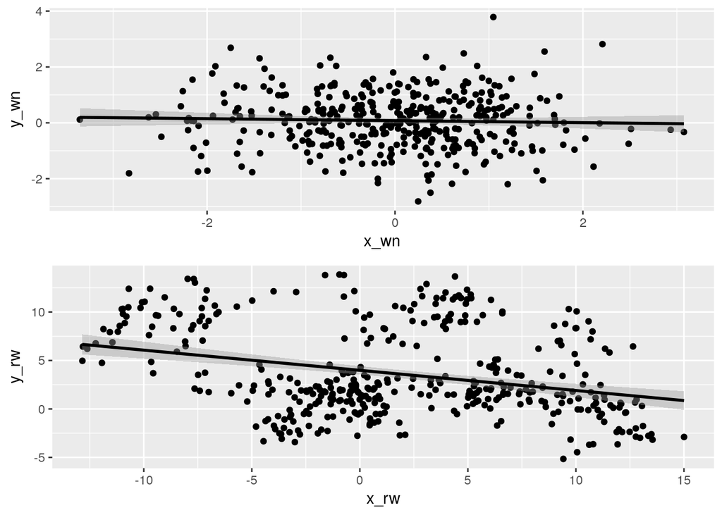

```r
df_wn <- tibble(x_wn =x_wn,y_wn=y_wn)
p_wn <- ggplot(df_wn,aes(x=x_wn,y=y_wn))+
  geom_point()+
  geom_smooth(method='lm',color=1)
df_rw <- tibble(x_rw=x_rw,y_rw=y_rw)
p_rw <- ggplot(df_rw,aes(x=x_rw,y=y_rw))+
  geom_point()+
  geom_smooth(method='lm',color=1)
grid.arrange(p_wn,p_rw)
```

つまり本当は何の関係もないのにxがyに関係しているかのような結果が得られた．

## AR過程からのサンプル

先ほどは単位根過程（ランダムウォーク）．

次はAR(1)過程からxとyをサンプリング．

```r
set.seed(2)
y_ar <- arima.sim(n_sample,
                  model=list(order=c(1,0,0),ar=c(0.8)))
x_ar <- arima.sim(n_sample,
                  model=list(order=c(1,0,0),ar=c(0.8)))
summary(lm(y_ar~x_ar))
```

```
##
## Call:
## lm(formula = y_ar ~ x_ar)
##
## Residuals:
##     Min      1Q  Median      3Q     Max
## -4.8320 -1.3404  0.0591  1.2246  4.6444
##
## Coefficients:
##             Estimate Std. Error t value Pr(>|t|)
## (Intercept)  0.47574    0.08906   5.342 1.55e-07 ***
## x_ar        -0.13483    0.04938  -2.731   0.0066 **
## ---
## Signif. codes:  0 '***' 0.001 '**' 0.01 '*' 0.05 '.' 0.1 ' ' 1
##
## Residual standard error: 1.754 on 398 degrees of freedom
## Multiple R-squared:  0.01839,    Adjusted R-squared:  0.01592
## F-statistic: 7.456 on 1 and 398 DF,  p-value: 0.006604
```

こちらも回帰係数は有意となった．

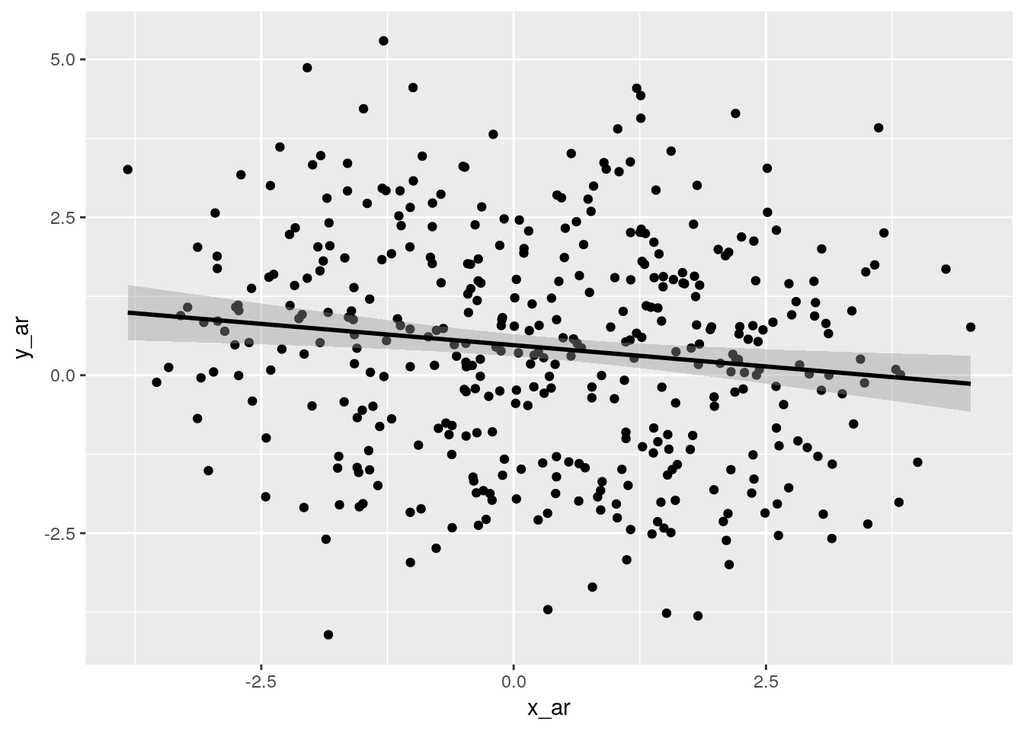

```r
df_ar <- tibble(x_ar =x_ar,y_wn=y_ar)
p_ar <- ggplot(df_wn,aes(x=x_ar,y=y_ar))+
  geom_point()+
  geom_smooth(method='lm',color=1)
p_ar
```

## Durbin-Watson(DW)検定

残差に自己相関があると，通常の最小自乗法は，問題が起きる(p125). これはのちにちゃんと説明する（多分）．

残差に自己相関があるかどうかをを検定する．

統計量は

$$DW = \frac{\sum_{t=2}^T(\hat{u}_t-\hat{u}_{t-1} )^2}{\sum_{t=1}^T\hat{u}_t^2},\\
\mbox{where. } \hat{u}_t = y_t-\hat{\beta}_0+\hat{\beta}_1x_t$$

簡単のため，xは１次元っぽく書いているが，r次元でもいい．DW統計量は帰無仮説（自己相関）0のもとでおよそ２．

```r
resid_ols <- model_ols_rw$residuals
dw <- sum(diff(resid_ols)^2) / sum(resid_ols^2)
dw
```

```
## [1] 0.05391462
```

大分2から離れているので自己相関はある．ちゃんと検定すると，

```r
lmtest::dwtest(model_ols_wn)
```

```
##
##  Durbin-Watson test
##
## data:  model_ols_wn
## DW = 1.9363, p-value = 0.262
## alternative hypothesis: true autocorrelation is greater than 0
```

```r
lmtest::dwtest(model_ols_rw)
```

```
##
##  Durbin-Watson test
##
## data:  model_ols_rw
## DW = 0.053915, p-value < 2.2e-16
## alternative hypothesis: true autocorrelation is greater than 0
```

よくみると片側検定になっている．両側でやる．

```r
lmtest::dwtest(model_ols_rw,alternative = "two.sided")
```

```
##
##  Durbin-Watson test
##
## data:  model_ols_rw
## DW = 0.053915, p-value < 2.2e-16
## alternative hypothesis: true autocorrelation is not 0
```

どちらにせよ棄却された．帰無分布は変わらないのでな．

## 割合を計算してみる

回帰係数のp値は次のように取得できる．

```r
coef <- summary(model_ols_wn)$coefficients
coef
```

```
##                Estimate Std. Error   t value  Pr(>|t|)
## (Intercept)  0.07696669 0.04895489  1.572196 0.1166997
## x_wn        -0.03565870 0.04754740 -0.749961 0.4537213
```

```r
coef["x_wn","Pr(>|t|)"]
```

```
## [1] 0.4537213
```

200回試みる．

```r
n_sim <- 200
n_sample <- 400
p_wn <- numeric(n_sim)
p_rw <- numeric(n_sim)
set.seed(1)
for(i in 1:n_sim){
  y_wn <- rnorm(n_sample)
  x_wn <- rnorm(n_sample)
  model_wn <- lm(y_wn~x_wn)
  p_wn[i] <- summary(model_wn)$coefficients["x_wn","Pr(>|t|)"]

  y_rw <- cumsum(rnorm(n_sample))
  x_rw <- cumsum(rnorm(n_sample))
  model_rw <- lm(y_rw~x_rw)
  p_rw[i] <- summary(model_rw)$coefficients["x_rw","Pr(>|t|)"]
}
```

```r
sum(p_wn<0.05)/n_sim
```

```
## [1] 0.055
```

```r
sum(p_rw<0.05)/n_sim
```

```
## [1] 0.85
```

## 見せかけの回帰を防ぐ

- ARIMAXやVAR,状態空間モデルで自己相関を表現する
- 一般化最小自乗法（GLS）で自己相関を組み込む
- 差分をとり自己相関をなくす．（実は共和分などの問題が起きうる）

### 差分をとり自己相関をなくす．（実は共和分などの問題が起きうる）

```r
summary(ur.df(y_rw,lags=1,type='none')) # 定数項もトレンドもなし
```

```
##
## ###############################################
## # Augmented Dickey-Fuller Test Unit Root Test #
## ###############################################
##
## Test regression none
##
##
## Call:
## lm(formula = z.diff ~ z.lag.1 - 1 + z.diff.lag)
##
## Residuals:
##      Min       1Q   Median       3Q      Max
## -2.69362 -0.76935 -0.01875  0.61984  3.10863
##
## Coefficients:
##             Estimate Std. Error t value Pr(>|t|)
## z.lag.1    -0.007932   0.008430  -0.941    0.347
## z.diff.lag -0.037636   0.050540  -0.745    0.457
##
## Residual standard error: 1 on 396 degrees of freedom
## Multiple R-squared:  0.004097,   Adjusted R-squared:  -0.0009326
## F-statistic: 0.8146 on 2 and 396 DF,  p-value: 0.4436
##
##
## Value of test-statistic is: -0.9409
##
## Critical values for test statistics:
##       1pct  5pct 10pct
## tau1 -2.58 -1.95 -1.62
```

「単位根を持つ」は棄却されない．

```r
summary(ur.df(y_ar,lags=1,type='none')) # 定数項もトレンドもなし
```

```
##
## ###############################################
## # Augmented Dickey-Fuller Test Unit Root Test #
## ###############################################
##
## Test regression none
##
##
## Call:
## lm(formula = z.diff ~ z.lag.1 - 1 + z.diff.lag)
##
## Residuals:
##      Min       1Q   Median       3Q      Max
## -2.74469 -0.63356  0.06323  0.80719  2.93191
##
## Coefficients:
##            Estimate Std. Error t value Pr(>|t|)
## z.lag.1    -0.17793    0.03005  -5.921 6.94e-09 ***
## z.diff.lag  0.01998    0.05042   0.396    0.692
## ---
## Signif. codes:  0 '***' 0.001 '**' 0.01 '*' 0.05 '.' 0.1 ' ' 1
##
## Residual standard error: 1.037 on 396 degrees of freedom
## Multiple R-squared:  0.08589,    Adjusted R-squared:  0.08128
## F-statistic:  18.6 on 2 and 396 DF,  p-value: 1.894e-08
##
##
## Value of test-statistic is: -5.9211
##
## Critical values for test statistics:
##       1pct  5pct 10pct
## tau1 -2.58 -1.95 -1.62
```

おっとここで終わりか．．．

### GLS

step

1. まず，自己相関にかかわるパラメータをOLSで推定
2. それを用いてデータを変換
3. 変換したデータにOLS